# Optimal Treatment Analysis

## Outcome Variable

**Outcome Variable:** ever_stunted

## Predictor Variables

**Intervention Variable:** vagbrth

**Adjustment Set:**

- arm
- sex
- W_mage
- meducyrs
- feducyrs
- hhwealth_quart
- W_mhtcm
- W_nrooms
- W_nchldlt5
- brthmon
- W_parity
- impfloor
- impsan
- safeh20
- delta_W_mage
- delta_meducyrs
- delta_feducyrs
- delta_hhwealth_quart
- delta_W_mhtcm
- delta_W_nrooms
- delta_W_nchldlt5
- delta_brthmon
- delta_W_parity
- delta_impfloor
- delta_impsan
- delta_safeh20

## Stratifying Variables

The analysis was stratified on these variable(s):

- agecat
- studyid
- country

## Data Summary

| agecat | studyid | country | vagbrth | ever_stunted | n_cell | n |
| --- | --- | --- | --- | --- | --- | --- |
| 0-24 months (no birth st.) | ki1000108-CMC-V-BCS-2002 | INDIA | 0 | 0 | 3 | 296 |
| 0-24 months (no birth st.) | ki1000108-CMC-V-BCS-2002 | INDIA | 0 | 1 | 17 | 296 |
| 0-24 months (no birth st.) | ki1000108-CMC-V-BCS-2002 | INDIA | 1 | 0 | 25 | 296 |
| 0-24 months (no birth st.) | ki1000108-CMC-V-BCS-2002 | INDIA | 1 | 1 | 251 | 296 |
| 0-24 months (no birth st.) | ki1000108-IRC | INDIA | 0 | 0 | 24 | 360 |
| 0-24 months (no birth st.) | ki1000108-IRC | INDIA | 0 | 1 | 35 | 360 |
| 0-24 months (no birth st.) | ki1000108-IRC | INDIA | 1 | 0 | 123 | 360 |
| 0-24 months (no birth st.) | ki1000108-IRC | INDIA | 1 | 1 | 178 | 360 |
| 0-24 months (no birth st.) | ki1017093b-PROVIDE | BANGLADESH | 0 | 0 | 97 | 634 |
| 0-24 months (no birth st.) | ki1017093b-PROVIDE | BANGLADESH | 0 | 1 | 46 | 634 |
| 0-24 months (no birth st.) | ki1017093b-PROVIDE | BANGLADESH | 1 | 0 | 299 | 634 |
| 0-24 months (no birth st.) | ki1017093b-PROVIDE | BANGLADESH | 1 | 1 | 192 | 634 |
| 0-24 months (no birth st.) | ki1017093c-NIH-Crypto | BANGLADESH | 0 | 0 | 117 | 432 |
| 0-24 months (no birth st.) | ki1017093c-NIH-Crypto | BANGLADESH | 0 | 1 | 58 | 432 |
| 0-24 months (no birth st.) | ki1017093c-NIH-Crypto | BANGLADESH | 1 | 0 | 136 | 432 |
| 0-24 months (no birth st.) | ki1017093c-NIH-Crypto | BANGLADESH | 1 | 1 | 121 | 432 |
| 0-24 months (no birth st.) | ki1066203-TanzaniaChild2 | TANZANIA, UNITED REPUBLIC OF | 0 | 0 | 145 | 2207 |
| 0-24 months (no birth st.) | ki1066203-TanzaniaChild2 | TANZANIA, UNITED REPUBLIC OF | 0 | 1 | 47 | 2207 |
| 0-24 months (no birth st.) | ki1066203-TanzaniaChild2 | TANZANIA, UNITED REPUBLIC OF | 1 | 0 | 1402 | 2207 |
| 0-24 months (no birth st.) | ki1066203-TanzaniaChild2 | TANZANIA, UNITED REPUBLIC OF | 1 | 1 | 613 | 2207 |
| 0-24 months (no birth st.) | ki1119695-PROBIT | BELARUS | 0 | 0 | 1640 | 16742 |
| 0-24 months (no birth st.) | ki1119695-PROBIT | BELARUS | 0 | 1 | 294 | 16742 |
| 0-24 months (no birth st.) | ki1119695-PROBIT | BELARUS | 1 | 0 | 12427 | 16742 |
| 0-24 months (no birth st.) | ki1119695-PROBIT | BELARUS | 1 | 1 | 2381 | 16742 |
| 0-24 months (no birth st.) | ki1126311-ZVITAMBO | ZIMBABWE | 0 | 0 | 731 | 12495 |
| 0-24 months (no birth st.) | ki1126311-ZVITAMBO | ZIMBABWE | 0 | 1 | 356 | 12495 |
| 0-24 months (no birth st.) | ki1126311-ZVITAMBO | ZIMBABWE | 1 | 0 | 7696 | 12495 |
| 0-24 months (no birth st.) | ki1126311-ZVITAMBO | ZIMBABWE | 1 | 1 | 3712 | 12495 |
| 0-24 months (no birth st.) | kiGH5241-JiVitA-3 | BANGLADESH | 0 | 0 | 1957 | 36761 |
| 0-24 months (no birth st.) | kiGH5241-JiVitA-3 | BANGLADESH | 0 | 1 | 396 | 36761 |

[output cut: 78 more lines]

The following strata were considered:

- agecat: 0-24 months (no birth st.), studyid: ki1000108-CMC-V-BCS-2002, country: INDIA
- agecat: 0-24 months (no birth st.), studyid: ki1000108-IRC, country: INDIA
- agecat: 0-24 months (no birth st.), studyid: ki1017093b-PROVIDE, country: BANGLADESH
- agecat: 0-24 months (no birth st.), studyid: ki1017093c-NIH-Crypto, country: BANGLADESH
- agecat: 0-24 months (no birth st.), studyid: ki1066203-TanzaniaChild2, country: TANZANIA, UNITED REPUBLIC OF
- agecat: 0-24 months (no birth st.), studyid: ki1119695-PROBIT, country: BELARUS
- agecat: 0-24 months (no birth st.), studyid: ki1126311-ZVITAMBO, country: ZIMBABWE
- agecat: 0-24 months (no birth st.), studyid: kiGH5241-JiVitA-3, country: BANGLADESH
- agecat: 0-24 months (no birth st.), studyid: kiGH5241-JiVitA-4, country: BANGLADESH
- agecat: 0-6 months (no birth st.), studyid: ki1000108-CMC-V-BCS-2002, country: INDIA
- agecat: 0-6 months (no birth st.), studyid: ki1000108-IRC, country: INDIA
- agecat: 0-6 months (no birth st.), studyid: ki1017093b-PROVIDE, country: BANGLADESH
- agecat: 0-6 months (no birth st.), studyid: ki1017093c-NIH-Crypto, country: BANGLADESH
- agecat: 0-6 months (no birth st.), studyid: ki1066203-TanzaniaChild2, country: TANZANIA, UNITED REPUBLIC OF
- agecat: 0-6 months (no birth st.), studyid: ki1119695-PROBIT, country: BELARUS
- agecat: 0-6 months (no birth st.), studyid: ki1126311-ZVITAMBO, country: ZIMBABWE
- agecat: 0-6 months (no birth st.), studyid: kiGH5241-JiVitA-3, country: BANGLADESH
- agecat: 0-6 months (no birth st.), studyid: kiGH5241-JiVitA-4, country: BANGLADESH
- agecat: 6-24 months, studyid: ki1000108-CMC-V-BCS-2002, country: INDIA
- agecat: 6-24 months, studyid: ki1000108-IRC, country: INDIA
- agecat: 6-24 months, studyid: ki1017093b-PROVIDE, country: BANGLADESH
- agecat: 6-24 months, studyid: ki1017093c-NIH-Crypto, country: BANGLADESH
- agecat: 6-24 months, studyid: ki1066203-TanzaniaChild2, country: TANZANIA, UNITED REPUBLIC OF
- agecat: 6-24 months, studyid: ki1119695-PROBIT, country: BELARUS
- agecat: 6-24 months, studyid: ki1126311-ZVITAMBO, country: ZIMBABWE
- agecat: 6-24 months, studyid: kiGH5241-JiVitA-3, country: BANGLADESH
- agecat: 6-24 months, studyid: kiGH5241-JiVitA-4, country: BANGLADESH

### Dropped Strata

Some strata were dropped due to rare outcomes:

- agecat: 0-24 months (no birth st.), studyid: ki1000108-CMC-V-BCS-2002, country: INDIA
- agecat: 6-24 months, studyid: ki1000108-CMC-V-BCS-2002, country: INDIA

## Methods Detail

We’re interested in the causal parameters $E[Y_a]$ for all values of $a \in \mathcal{A}$. These parameters represent the mean outcome if, possibly contrary to fact, we intervened to set all units to have $A=a$. Under the randomization and positivity assumptions, these are identified by the statistical parameters $\psi_a=E_W[E_{Y|A,W}(Y|A=a,W)]$. In addition, we’re interested in the mean of $Y$, $E[Y]$ under no intervention (the observed mean). We will estimate these parameters by using SuperLearner to fit the relevant likelihood factors – $E_{Y|A,W}(Y|A=a,W)$ and $p(A=a|W)$, and then updating our likelihood fit using a joint TMLE.

For unadjusted analyses ($W=\{\}$), initial likelihoods were estimated using Lrnr_glm to estimate the simple $E(Y|A)$ and Lrnr_mean to estimate $p(A)$. For adjusted analyses, a small library containing Lrnr_glmnet, Lrnr_xgboost, and Lrnr_mean was used.

Having estimated these parameters, we will then use the delta method to estimate relative risks and attributable risks relative to a prespecified baseline level of $A$.

# Results Detail

## Results Plots

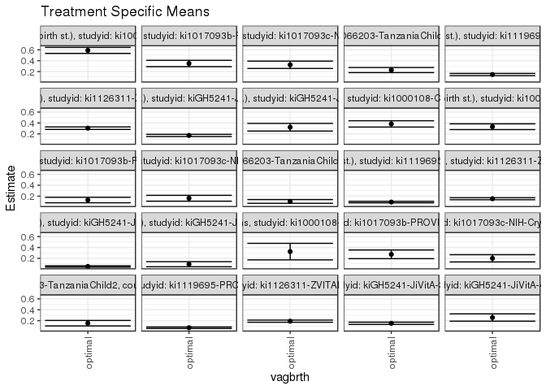

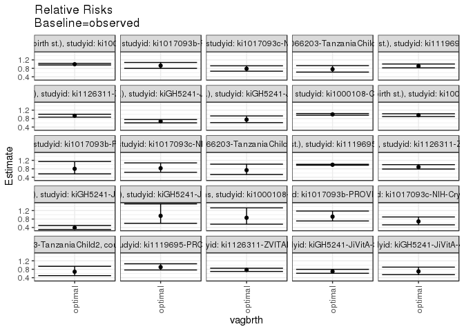

## Results Table

### Parameter: TSM

| agecat | studyid | country | intervention_level | baseline_level | estimate | ci_lower | ci_upper |
| --- | --- | --- | --- | --- | --- | --- | --- |
| 0-24 months (no birth st.) | ki1000108-IRC | INDIA | optimal | NA | 0.5890760 | 0.5337889 | 0.6443631 |
| 0-24 months (no birth st.) | ki1017093b-PROVIDE | BANGLADESH | optimal | NA | 0.3485420 | 0.2901537 | 0.4069303 |
| 0-24 months (no birth st.) | ki1017093c-NIH-Crypto | BANGLADESH | optimal | NA | 0.3247825 | 0.2574018 | 0.3921631 |
| 0-24 months (no birth st.) | ki1066203-TanzaniaChild2 | TANZANIA, UNITED REPUBLIC OF | optimal | NA | 0.2276979 | 0.1809528 | 0.2744430 |
| 0-24 months (no birth st.) | ki1119695-PROBIT | BELARUS | optimal | NA | 0.1453398 | 0.1250875 | 0.1655921 |
| 0-24 months (no birth st.) | ki1126311-ZVITAMBO | ZIMBABWE | optimal | NA | 0.3042492 | 0.2808471 | 0.3276513 |
| 0-24 months (no birth st.) | kiGH5241-JiVitA-3 | BANGLADESH | optimal | NA | 0.1706122 | 0.1504435 | 0.1907810 |
| 0-24 months (no birth st.) | kiGH5241-JiVitA-4 | BANGLADESH | optimal | NA | 0.3214739 | 0.2510948 | 0.3918530 |
| 0-6 months (no birth st.) | ki1000108-CMC-V-BCS-2002 | INDIA | optimal | NA | 0.3824175 | 0.3245664 | 0.4402685 |
| 0-6 months (no birth st.) | ki1000108-IRC | INDIA | optimal | NA | 0.3311390 | 0.2781531 | 0.3841250 |
| 0-6 months (no birth st.) | ki1017093b-PROVIDE | BANGLADESH | optimal | NA | 0.1278158 | 0.0774927 | 0.1781389 |
| 0-6 months (no birth st.) | ki1017093c-NIH-Crypto | BANGLADESH | optimal | NA | 0.1609372 | 0.1068356 | 0.2150388 |
| 0-6 months (no birth st.) | ki1066203-TanzaniaChild2 | TANZANIA, UNITED REPUBLIC OF | optimal | NA | 0.1020696 | 0.0674648 | 0.1366744 |
| 0-6 months (no birth st.) | ki1119695-PROBIT | BELARUS | optimal | NA | 0.0907616 | 0.0770317 | 0.1044914 |
| 0-6 months (no birth st.) | ki1126311-ZVITAMBO | ZIMBABWE | optimal | NA | 0.1517048 | 0.1332560 | 0.1701535 |
| 0-6 months (no birth st.) | kiGH5241-JiVitA-3 | BANGLADESH | optimal | NA | 0.0511036 | 0.0386309 | 0.0635763 |
| 0-6 months (no birth st.) | kiGH5241-JiVitA-4 | BANGLADESH | optimal | NA | 0.0930127 | 0.0464506 | 0.1395747 |
| 6-24 months | ki1000108-IRC | INDIA | optimal | NA | 0.3242779 | 0.1726084 | 0.4759475 |
| 6-24 months | ki1017093b-PROVIDE | BANGLADESH | optimal | NA | 0.2743118 | 0.1945284 | 0.3540953 |
| 6-24 months | ki1017093c-NIH-Crypto | BANGLADESH | optimal | NA | 0.2009262 | 0.1341764 | 0.2676760 |
| 6-24 months | ki1066203-TanzaniaChild2 | TANZANIA, UNITED REPUBLIC OF | optimal | NA | 0.1535636 | 0.1030177 | 0.2041095 |
| 6-24 months | ki1119695-PROBIT | BELARUS | optimal | NA | 0.0694620 | 0.0560317 | 0.0828923 |
| 6-24 months | ki1126311-ZVITAMBO | ZIMBABWE | optimal | NA | 0.1898928 | 0.1699318 | 0.2098537 |
| 6-24 months | kiGH5241-JiVitA-3 | BANGLADESH | optimal | NA | 0.1509794 | 0.1305326 | 0.1714263 |
| 6-24 months | kiGH5241-JiVitA-4 | BANGLADESH | optimal | NA | 0.2571610 | 0.1897778 | 0.3245442 |

### Parameter: E(Y)

| agecat | studyid | country | intervention_level | baseline_level | estimate | ci_lower | ci_upper |
| --- | --- | --- | --- | --- | --- | --- | --- |
| 0-24 months (no birth st.) | ki1000108-IRC | INDIA | observed | NA | 0.5915221 | 0.5406773 | 0.6423669 |
| 0-24 months (no birth st.) | ki1017093b-PROVIDE | BANGLADESH | observed | NA | 0.3749049 | 0.3371831 | 0.4126268 |
| 0-24 months (no birth st.) | ki1017093c-NIH-Crypto | BANGLADESH | observed | NA | 0.4147326 | 0.3682262 | 0.4612390 |
| 0-24 months (no birth st.) | ki1066203-TanzaniaChild2 | TANZANIA, UNITED REPUBLIC OF | observed | NA | 0.2992517 | 0.2801461 | 0.3183573 |
| 0-24 months (no birth st.) | ki1119695-PROBIT | BELARUS | observed | NA | 0.1596733 | 0.1407169 | 0.1786296 |
| 0-24 months (no birth st.) | ki1126311-ZVITAMBO | ZIMBABWE | observed | NA | 0.3257496 | 0.3175331 | 0.3339662 |
| 0-24 months (no birth st.) | kiGH5241-JiVitA-3 | BANGLADESH | observed | NA | 0.2537774 | 0.2459689 | 0.2615859 |
| 0-24 months (no birth st.) | kiGH5241-JiVitA-4 | BANGLADESH | observed | NA | 0.4281704 | 0.4076539 | 0.4486868 |
| 0-6 months (no birth st.) | ki1000108-CMC-V-BCS-2002 | INDIA | observed | NA | 0.3829983 | 0.3271302 | 0.4388664 |
| 0-6 months (no birth st.) | ki1000108-IRC | INDIA | observed | NA | 0.3447553 | 0.2956006 | 0.3939101 |
| 0-6 months (no birth st.) | ki1017093b-PROVIDE | BANGLADESH | observed | NA | 0.1595696 | 0.1310607 | 0.1880786 |
| 0-6 months (no birth st.) | ki1017093c-NIH-Crypto | BANGLADESH | observed | NA | 0.1945436 | 0.1571794 | 0.2319077 |
| 0-6 months (no birth st.) | ki1066203-TanzaniaChild2 | TANZANIA, UNITED REPUBLIC OF | observed | NA | 0.1388225 | 0.1244213 | 0.1532237 |
| 0-6 months (no birth st.) | ki1119695-PROBIT | BELARUS | observed | NA | 0.0914989 | 0.0783793 | 0.1046184 |
| 0-6 months (no birth st.) | ki1126311-ZVITAMBO | ZIMBABWE | observed | NA | 0.1711344 | 0.1645285 | 0.1777402 |
| 0-6 months (no birth st.) | kiGH5241-JiVitA-3 | BANGLADESH | observed | NA | 0.1314742 | 0.1258236 | 0.1371249 |
| 0-6 months (no birth st.) | kiGH5241-JiVitA-4 | BANGLADESH | observed | NA | 0.0978168 | 0.0850307 | 0.1106029 |
| 6-24 months | ki1000108-IRC | INDIA | observed | NA | 0.3771648 | 0.3151984 | 0.4391311 |
| 6-24 months | ki1017093b-PROVIDE | BANGLADESH | observed | NA | 0.3004545 | 0.2584027 | 0.3425064 |
| 6-24 months | ki1017093c-NIH-Crypto | BANGLADESH | observed | NA | 0.2921808 | 0.2426565 | 0.3417050 |
| 6-24 months | ki1066203-TanzaniaChild2 | TANZANIA, UNITED REPUBLIC OF | observed | NA | 0.2246352 | 0.2040709 | 0.2451994 |
| 6-24 months | ki1119695-PROBIT | BELARUS | observed | NA | 0.0771391 | 0.0631738 | 0.0911044 |
| 6-24 months | ki1126311-ZVITAMBO | ZIMBABWE | observed | NA | 0.2472516 | 0.2377515 | 0.2567517 |
| 6-24 months | kiGH5241-JiVitA-3 | BANGLADESH | observed | NA | 0.2169190 | 0.2075863 | 0.2262516 |
| 6-24 months | kiGH5241-JiVitA-4 | BANGLADESH | observed | NA | 0.3673044 | 0.3464282 | 0.3881806 |

### Parameter: RR

| agecat | studyid | country | intervention_level | baseline_level | estimate | ci_lower | ci_upper |
| --- | --- | --- | --- | --- | --- | --- | --- |
| 0-24 months (no birth st.) | ki1000108-IRC | INDIA | optimal | observed | 0.9958647 | 0.9589420 | 1.0342092 |
| 0-24 months (no birth st.) | ki1017093b-PROVIDE | BANGLADESH | optimal | observed | 0.9296810 | 0.8001541 | 1.0801752 |
| 0-24 months (no birth st.) | ki1017093c-NIH-Crypto | BANGLADESH | optimal | observed | 0.7831130 | 0.6662644 | 0.9204543 |
| 0-24 months (no birth st.) | ki1066203-TanzaniaChild2 | TANZANIA, UNITED REPUBLIC OF | optimal | observed | 0.7608909 | 0.6240163 | 0.9277881 |
| 0-24 months (no birth st.) | ki1119695-PROBIT | BELARUS | optimal | observed | 0.9102324 | 0.8240469 | 1.0054318 |
| 0-24 months (no birth st.) | ki1126311-ZVITAMBO | ZIMBABWE | optimal | observed | 0.9339971 | 0.8677129 | 1.0053448 |
| 0-24 months (no birth st.) | kiGH5241-JiVitA-3 | BANGLADESH | optimal | observed | 0.6722909 | 0.5986820 | 0.7549501 |
| 0-24 months (no birth st.) | kiGH5241-JiVitA-4 | BANGLADESH | optimal | observed | 0.7508083 | 0.6087935 | 0.9259513 |
| 0-6 months (no birth st.) | ki1000108-CMC-V-BCS-2002 | INDIA | optimal | observed | 0.9984834 | 0.9594170 | 1.0391406 |
| 0-6 months (no birth st.) | ki1000108-IRC | INDIA | optimal | observed | 0.9605045 | 0.8977431 | 1.0276534 |
| 0-6 months (no birth st.) | ki1017093b-PROVIDE | BANGLADESH | optimal | observed | 0.8010036 | 0.5607450 | 1.1442041 |
| 0-6 months (no birth st.) | ki1017093c-NIH-Crypto | BANGLADESH | optimal | observed | 0.8272552 | 0.6338790 | 1.0796242 |
| 0-6 months (no birth st.) | ki1066203-TanzaniaChild2 | TANZANIA, UNITED REPUBLIC OF | optimal | observed | 0.7352524 | 0.5301395 | 1.0197242 |
| 0-6 months (no birth st.) | ki1119695-PROBIT | BELARUS | optimal | observed | 0.9919419 | 0.9699528 | 1.0144294 |
| 0-6 months (no birth st.) | ki1126311-ZVITAMBO | ZIMBABWE | optimal | observed | 0.8864659 | 0.7887256 | 0.9963183 |
| 0-6 months (no birth st.) | kiGH5241-JiVitA-3 | BANGLADESH | optimal | observed | 0.3886968 | 0.3057089 | 0.4942127 |
| 0-6 months (no birth st.) | kiGH5241-JiVitA-4 | BANGLADESH | optimal | observed | 0.9508865 | 0.5961907 | 1.5166039 |
| 6-24 months | ki1000108-IRC | INDIA | optimal | observed | 0.8597779 | 0.5567823 | 1.3276609 |
| 6-24 months | ki1017093b-PROVIDE | BANGLADESH | optimal | observed | 0.9129895 | 0.7079297 | 1.1774471 |
| 6-24 months | ki1017093c-NIH-Crypto | BANGLADESH | optimal | observed | 0.6876778 | 0.5264970 | 0.8982023 |
| 6-24 months | ki1066203-TanzaniaChild2 | TANZANIA, UNITED REPUBLIC OF | optimal | observed | 0.6836134 | 0.4978334 | 0.9387221 |
| 6-24 months | ki1119695-PROBIT | BELARUS | optimal | observed | 0.9004775 | 0.7663306 | 1.0581068 |
| 6-24 months | ki1126311-ZVITAMBO | ZIMBABWE | optimal | observed | 0.7680143 | 0.6960374 | 0.8474343 |
| 6-24 months | kiGH5241-JiVitA-3 | BANGLADESH | optimal | observed | 0.6960177 | 0.6090485 | 0.7954057 |
| 6-24 months | kiGH5241-JiVitA-4 | BANGLADESH | optimal | observed | 0.7001304 | 0.5437744 | 0.9014446 |